# CSSAWorkshop slides

[figure not shown]

## [Sign In Here](https://forms.gle/QQerJxF38V5jQDSQ6)

## Some Important Notes

- Make a copy of the entire Google Drive folder to your Google Drive.
- Make sure you run each cell as you follow along. You can run a cell by pressing `Shift` + `Enter`.
- If you run into trouble, (i.e. you ran the cells out of order), go to the top navigation. Click `Runtime` > `Restart and run all`, you may see some errors later in the notebook but don't worry about those yet.

[figure not shown]

# Introduction to Data Analytics with Python

## Packages

#### [**pandas**](https://pandas.pydata.org/docs/user_guide/index.html)

- a python library for data wrangling, analytics, and manipulation.

#### [**bs4**](https://www.crummy.com/software/BeautifulSoup/bs4/doc/)

- (Beautiful Soup) a python library for extracting data from webpages.

#### [**numpy**](https://numpy.org/doc/)

- a python library for performing high-level math function (arrays, matrices)

#### [**matplotlib**](https://matplotlib.org/users/index.html)

- a python library for visualizing data

```python
# import packages
import pandas as pd
import bs4

import numpy as np
import matplotlib.pyplot as plt
```

## Importing the CAPE Data File

- In the Google Drive Folder you should see a file titled: `capeData.htm`
- Download the file.
- Click the folder icon on the left side of the Google Colab

[figure not shown]

- Upload the file

[figure not shown]

[figure not shown]

- You should see this message! Click `OK`

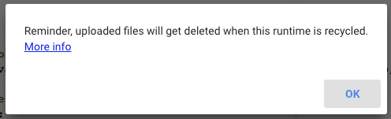

- Now you should see the `capeData.htm` file on the left. Please leave a message in the chat if you are still having trouble uploading the file.

[figure not shown]

```python
from bs4 import BeautifulSoup

with open("capeData.htm") as fp:
    soup = BeautifulSoup(fp, 'html.parser')

title_page = soup.title.string
```

## Data Scraping

```python
# extract data from HTML table
cape_table = soup.find('tbody')

# create arrays to store each variable
instructor, course, term, enroll, evals_made, rcmnd_class, rcmnd_instr, study_hrs, avg_grd_exp, avg_grd_rec = [], [], [], [], [], [], [], [], [], []

# loop through each row in the table and extract data
for row in cape_table.findAll('tr'):

    cells = row.findAll('td')

    # This catches when the name cells stops having a link
    #  and ends, skipping the last (summary rows)

    try:
        instructor.append(cells[0].find(text=True))
        course.append(cells[1].find('a').text)
        term.append(cells[2].find(text=True))
        enroll.append(cells[3].find(text=True))
        evals_made.append(cells[4].find('span').text)
        rcmnd_class.append(cells[5].find('span').text)
        rcmnd_instr.append(cells[6].find('span').text)
        study_hrs.append(cells[7].find('span').text)
        avg_grd_exp.append(cells[8].find('span').text)
        avg_grd_rec.append(cells[9].find('span').text)
    except:
        break
```

### Dataframes

The main functionalities in pandas is to organize and analyze data in dataframes, which are similar to spreadsheets.

They are very useful for altering or manipulating a large volume of data with a few simple functions.

Pandas and python is also convenient in that it can automate routine tasks. (Note: there's even a book called *Automate the Boring Stuff with Python*)

```python
# add data to a pandas dataframe
cape_df = pd.DataFrame(data={'Instructor': instructor, 'Course': course,
                             'Term': term, 'Enroll': enroll,
                             'Evaluations': evals_made, 'Recommend Class (%)': rcmnd_class,
                             'Recommend Instructor (%)': rcmnd_instr,
                             'Study Hours': study_hrs,
                             'Average Grade Expected': avg_grd_exp,
                             'Average Grade Received': avg_grd_rec})

cape_df
```

|  | Instructor | Course | Term | Enroll | Evaluations | Recommend Class (%) | Recommend Instructor (%) | Study Hours | Average Grade Expected | Average Grade Received |
| --- | --- | --- | --- | --- | --- | --- | --- | --- | --- | --- |
| 0 | Barrera, Steven James | COGS 1 - Introduction to Cognitive Sci (A) | FA20 | 487 | 255 | 98.8% | 99.6% | 4.18 | A- (3.76) | B+ (3.61) |
| 1 | Scott, Taylor Jackson | COGS 10 - Cognitv Consequence/Technology (A) | FA20 | 296 | 244 | 96.3% | 99.2% | 3.68 | A- (3.85) | A- (3.82) |
| 2 | Xia, Haijun | COGS 10 - Cognitv Consequence/Technology (B) | FA20 | 200 | 171 | 94.2% | 98.2% | 3.96 | A- (3.75) | A- (3.78) |
| 3 | Kirsh, David Joel | COGS 100 - Cyborgs Now and in the Future (A) | FA20 | 318 | 267 | 75.3% | 85.8% | 5.86 | B+ (3.61) | B+ (3.42) |
| 4 | Hoffman, Drew Ellen | COGS 101A - Sensation and Perception (A) | FA20 | 284 | 152 | 95.9% | 97.3% | 4.73 | B+ (3.64) | B+ (3.44) |
| ... | ... | ... | ... | ... | ... | ... | ... | ... | ... | ... |
| 1105 | Becvar, Laura A. | COGS 10 - Cognitv Consequence/Technology (A) | SU07 | 12 | 6 | 100.0% | 100.0% | 5.70 | B+ (3.50) | N/A |
| 1106 | Robinson, Alan E. | COGS 101B - Learning, Memory and Attention (A) | SU07 | 24 | 19 | 84.2% | 66.7% | 6.61 | B (3.26) | N/A |
| 1107 | Groppe, David M | COGS 14 - Design & Analysis of Expermnts (A) | SU07 | 20 | 15 | 93.3% | 100.0% | 3.17 | B+ (3.62) | N/A |
| 1108 | Pineda, Jaime A | COGS 160 - Seminar on Special Topics (A) | SU07 | 10 | 6 | 100.0% | 100.0% | 9.17 | A- (3.80) | N/A |
| 1109 | Pineda, Jaime A | COGS 17 - Neurobiology of Cognition (A) | SU07 | 21 | 17 | 94.1% | 100.0% | 5.44 | B+ (3.57) | N/A |

1110 rows × 10 columns

## Data Cleaning

One of the most necessary skills in data analytics needs is the ability to clean data.

After importing data into data frames, the data is normally very "messy."

Ex. missing data/NA values, incorrect/unconverted data types, unstandardized data, misordered data, unusable data etc.

Cleaning data often requires addressing most or all of the above issues.

Pandas makes this much easier to deal with.

### Dealing with Missing Data

- Often times you will not have a complete dataset
- It is important that you evaluate your options when it comes to missing data
  - Deleting the values completely
  - Setting the values to 0

In this case we decided to delete the values in order to not skew the data.

```python
# Drop rows with N/A values

cape_df = cape_df[cape_df['Average Grade Received'] != 'N/A']
cape_df = cape_df[cape_df['Average Grade Expected'] != 'N/A']
```

### Standardizing Data

- Data isn't perfect. So we need to standardize data inputs.
  - incorrect spelling
  - lots of spaces
  - duplicate inputs
  - inconsistent capitalization

Ex: In our dataframe we have:

```
'COGS 1 - Introduction to Cognitive Sci (A)',
'COGS 1 - Introduction to Cognitive Sci (B)',
'COGS 1   - Introduction to Cognitive Sci  (A)',
'COGS 1 - Introduction to Cognitive Sci  (A)',
```

When we really just want:

```
'COGS 1 - Introduction to Cognitive Sci'
```

```python
# Standardize Course Name (get rid of section)

def stnd_course(course):
  course = str(course)
  course = course.strip()
  temp = course.split('-')
  temp[0] = temp[0].strip()
  temp[1] = temp[1].strip()
  course = temp[0] + ' - ' + temp[1]
  course.strip()
  return course [:-4]

cape_df['Course'] = cape_df['Course'].apply(stnd_course)
cape_df['Course'] = cape_df['Course'].str.strip()
```

```python
# Standardize the Instructor Name (get rid of whitespaces)
cape_df['Instructor'] = cape_df['Instructor'].str.strip()
```

### Incorrect/Unconverted Data Types

Currently every column's data type in our dataframe is an object when we want numerical types because numerical types are easier to perform data analysis on.

Currently the data types we have are:

```
Instructor                  object
Course                      object
Term                        object
Enroll                      object
Evaluations                 object
Recommend Class (%)         object
Recommend Instructor (%)    object
Study Hours                 object
Average Grade Expected      object
Average Grade Received      object
dtype: object
```

We want:

```
Instructor                   object
Course                       object
Term                         object
Year                          int64
Quarter                       int64
Enroll                        int64
Evaluations                   int64
Recommend Class (%)         float64
Recommend Instructor (%)    float64
Study Hours                 float64
Average Grade Expected       object
GPA Expected                float64
Average Grade Received       object
GPA Received                float64
dtype: object
```

```python
# maps each quarter to a numerical value
quarter_map = {'FA': 1, 'WI': 2, 'SP': 3, 'SU':4, 'S1': 4, 'S2':5}

def getYear(term):
  return int(term[2:])

def getQuarter(term):
  return quarter_map[term[0:2]]

Year = cape_df['Term'].apply(getYear)
Quarter = cape_df['Term'].apply(getQuarter)

cape_df.insert(3, "Year", Year, True)
cape_df.insert(4, "Quarter", Quarter, True)
```

```python
# Add Average Grade Expected and Average Grade Received in terms in GPA

def to_gpa(grade):
  return float(grade[-5:len(grade)-1])

GPA_Expected = cape_df['Average Grade Expected'].apply(to_gpa)
GPA_Received = cape_df['Average Grade Received'].apply(to_gpa)

cape_df.insert(11, "GPA Expected", GPA_Expected)
cape_df.insert(13, "GPA Received", GPA_Received)
```

```python
# Convert Recommend Class, Recommend Instructor columns to floats

def to_num(rec):
  return float(rec[:len(rec)-1])

cape_df['Recommend Class (%)'] = cape_df['Recommend Class (%)'].apply(to_num)
cape_df['Recommend Instructor (%)'] = cape_df['Recommend Instructor (%)'].apply(to_num)
```

```python
# Convert the rest of the columns to numerical values
cape_df[['Enroll', 'Evaluations', 'Study Hours']] = cape_df[['Enroll', 'Evaluations', 'Study Hours']].apply(pd.to_numeric)
```

```python
cape_df
```

|  | Instructor | Course | Term | Year | Quarter | Enroll | Evaluations | Recommend Class (%) | Recommend Instructor (%) | Study Hours | Average Grade Expected | GPA Expected | Average Grade Received | GPA Received |
| --- | --- | --- | --- | --- | --- | --- | --- | --- | --- | --- | --- | --- | --- | --- |
| 0 | Barrera, Steven James | COGS 1 - Introduction to Cognitive Sci | FA20 | 20 | 1 | 487 | 255 | 98.8 | 99.6 | 4.18 | A- (3.76) | 3.76 | B+ (3.61) | 3.61 |
| 1 | Scott, Taylor Jackson | COGS 10 - Cognitv Consequence/Technology | FA20 | 20 | 1 | 296 | 244 | 96.3 | 99.2 | 3.68 | A- (3.85) | 3.85 | A- (3.82) | 3.82 |
| 2 | Xia, Haijun | COGS 10 - Cognitv Consequence/Technology | FA20 | 20 | 1 | 200 | 171 | 94.2 | 98.2 | 3.96 | A- (3.75) | 3.75 | A- (3.78) | 3.78 |
| 3 | Kirsh, David Joel | COGS 100 - Cyborgs Now and in the Future | FA20 | 20 | 1 | 318 | 267 | 75.3 | 85.8 | 5.86 | B+ (3.61) | 3.61 | B+ (3.42) | 3.42 |
| 4 | Hoffman, Drew Ellen | COGS 101A - Sensation and Perception | FA20 | 20 | 1 | 284 | 152 | 95.9 | 97.3 | 4.73 | B+ (3.64) | 3.64 | B+ (3.44) | 3.44 |
| ... | ... | ... | ... | ... | ... | ... | ... | ... | ... | ... | ... | ... | ... | ... |
| 1097 | Simpkins, Charles Alexander | COGS 109 - Modeling & Data Analysis | FA07 | 7 | 1 | 103 | 53 | 75.0 | 98.1 | 6.15 | B+ (3.52) | 3.52 | B+ (3.34) | 3.34 |
| 1098 | Hollan, James D. | COGS 120 - Human Computer Interaction | FA07 | 7 | 1 | 53 | 27 | 88.9 | 96.3 | 3.83 | B+ (3.65) | 3.65 | B+ (3.38) | 3.38 |
| 1101 | Johnson, Christine M. | COGS 17 - Neurobiology of Cognition | FA07 | 7 | 1 | 114 | 70 | 84.1 | 88.4 | 4.41 | B (3.19) | 3.19 | C+ (2.62) | 2.62 |
| 1102 | Marx, Susan S | COGS 18 - Intr/C Programming/Cogntv Modl | FA07 | 7 | 1 | 90 | 39 | 78.9 | 97.2 | 5.29 | B+ (3.51) | 3.51 | B- (2.93) | 2.93 |
| 1103 | Wallen, Mark R. | COGS 3 - Introduction to Computing | FA07 | 7 | 1 | 104 | 54 | 86.5 | 92.3 | 3.31 | B+ (3.50) | 3.50 | B (3.16) | 3.16 |

853 rows × 14 columns

## Data Analysis

```python
cape_df.shape
```

```
(853, 14)
```

(rows, columns)

```python
cape_df.describe()
```

|  | Year | Quarter | Enroll | Evaluations | Recommend Class (%) | Recommend Instructor (%) | Study Hours | GPA Expected | GPA Received |
| --- | --- | --- | --- | --- | --- | --- | --- | --- | --- |
| count | 853.000000 | 853.000000 | 853.000000 | 853.000000 | 853.000000 | 853.000000 | 853.000000 | 853.000000 | 853.000000 |
| mean | 15.351700 | 2.373974 | 123.620164 | 62.851114 | 86.765416 | 88.261313 | 5.451958 | 3.467304 | 3.310832 |
| std | 3.716555 | 1.184655 | 103.278493 | 64.264018 | 12.209409 | 12.884700 | 1.830695 | 0.254101 | 0.358061 |
| min | 7.000000 | 1.000000 | 20.000000 | 3.000000 | 26.700000 | 30.900000 | 1.900000 | 2.250000 | 2.080000 |
| 25% | 12.000000 | 1.000000 | 44.000000 | 19.000000 | 81.400000 | 83.300000 | 4.210000 | 3.290000 | 3.050000 |
| 50% | 16.000000 | 2.000000 | 89.000000 | 41.000000 | 90.000000 | 92.200000 | 5.090000 | 3.470000 | 3.310000 |
| 75% | 19.000000 | 3.000000 | 170.000000 | 84.000000 | 95.500000 | 97.800000 | 6.210000 | 3.660000 | 3.600000 |
| max | 20.000000 | 5.000000 | 504.000000 | 426.000000 | 100.000000 | 100.000000 | 13.890000 | 4.000000 | 4.000000 |

Note: not all of these values are meaningful

### Let's Find the Lowest Average Grade Ever

```python
# what was the lowest average gpa received?
cape_df['GPA Received'].min()
```

```
2.08
```

```python
# let's store this value in a variable
lowest_gpa_EVER = cape_df['GPA Received'].min()
```

```python
# let's gather more information about this value.
# Q: Who was the Instructor that gave the lowest average GPA?
# Q: What do you think the Instructor's recommendation rate was?
# Q: Which Quarter was this grade given?

cape_df[cape_df['GPA Received'] == lowest_gpa_EVER]
```

|  | Instructor | Course | Term | Year | Quarter | Enroll | Evaluations | Recommend Class (%) | Recommend Instructor (%) | Study Hours | Average Grade Expected | GPA Expected | Average Grade Received | GPA Received |
| --- | --- | --- | --- | --- | --- | --- | --- | --- | --- | --- | --- | --- | --- | --- |
| 1072 | Nunez, Rafael E | COGS 14 - Design & Analysis of Expermnts | SP08 | 8 | 3 | 94 | 64 | 55.0 | 98.3 | 3.96 | B- (2.98) | 2.98 | C (2.08) | 2.08 |

### Let's Find the Highest Average Grade Ever

```
# try it! - highest avg grade ever
highest_gpa_EVER = # fill this in!
print(highest_gpa_EVER)

cape_df[cape_df['GPA Received'] == # fill this in!]
```

```python
# try it! - highest avg grade ever
highest_gpa_EVER = cape_df['GPA Received'].max()
print(highest_gpa_EVER)

cape_df[cape_df['GPA Received'] == highest_gpa_EVER]
```

```
4.0
```

|  | Instructor | Course | Term | Year | Quarter | Enroll | Evaluations | Recommend Class (%) | Recommend Instructor (%) | Study Hours | Average Grade Expected | GPA Expected | Average Grade Received | GPA Received |
| --- | --- | --- | --- | --- | --- | --- | --- | --- | --- | --- | --- | --- | --- | --- |
| 93 | Chiba, Andrea | COGS 164 - Neurobiology of Motivation | SP20 | 20 | 3 | 75 | 27 | 100.0 | 100.0 | 4.06 | A- (3.93) | 3.93 | A (4.00) | 4.0 |
| 476 | Boyle, Mary E. T. | COGS 11 - Minds & Brains | S116 | 16 | 4 | 23 | 7 | 85.7 | 85.7 | 5.64 | B+ (3.40) | 3.40 | A (4.00) | 4.0 |
| 538 | Boroditsky, Lera | COGS 12 - Language, Culture & Cognition | FA15 | 15 | 1 | 33 | 17 | 93.8 | 93.8 | 2.50 | B+ (3.60) | 3.60 | A (4.00) | 4.0 |
| 640 | Boyle, Mary E. T. | COGS 187A - Usability & Info. Architecture | S214 | 14 | 5 | 20 | 11 | 90.0 | 100.0 | 5.10 | A (4.00) | 4.00 | A (4.00) | 4.0 |
| 693 | De Sa, Virginia | COGS 189 - Brain Computer Interfaces | WI14 | 14 | 2 | 20 | 9 | 100.0 | 100.0 | 5.93 | A- (3.88) | 3.88 | A (4.00) | 4.0 |

### Let's Find the Average Grade Given by Professor

```python
# avg grade given by professor

"""
Some Professors you can choose from:
'Barrera, Steven James'
'De Sa, Virginia'
'Boyle, Mary E. T.'
'Scott, Taylor Jackson'
'Ellis, Shannon Elizabeth'
'Kirsh, David Joel'
'Guo, Philip J'
'Johnson, Christine M.'
"""

# Play around with the inputs!
cape_df[cape_df['Instructor'] == 'Johnson, Christine M.']['GPA Received'].mean()
```

```
3.116582278481013
```

```python
# find all the average grades given by each professor

instr_gpa_df = cape_df[['Instructor','GPA Received']]
instr_gpa_df.groupby(['Instructor']).mean()
```

| Instructor | GPA Received |
| --- | --- |
| Adrian, Julia Anna | 3.260000 |
| Alexander, Andrew Spencer | 3.095000 |
| Alfonso, Stephanie Isabel | 3.113333 |
| Allen, Michael Gordon | 3.587500 |
| Amsel, Ben David | 3.155000 |
| ... | ... |
| Weibel, Nadir | 3.373333 |
| Xia, Haijun | 3.780000 |
| Yang, Dorothy D | 2.990000 |
| Yang, Dorothy Daw-Shin | 3.017143 |
| Yu, Angela J. | 3.466000 |

101 rows × 1 columns

### Highest Recommended Instructor

```python
# highest recommended instructor
high_rec_inst = cape_df['Recommend Instructor (%)'].max()
high_rec_inst_df = cape_df[cape_df['Recommend Instructor (%)'] == high_rec_inst]

high_rec_inst_df['Instructor'].unique()
```

```
array(['Barrera, Steven James', 'Deak, Gedeon O.', 'De Sa, Virginia',
       'Dow, Steven P', 'Guo, Philip J', 'Bergen, Benjamin',
       'Tu, Zhuowen', 'Leonardis, Eric Jeffrey', 'Adrian, Julia Anna',
       'Trott, Sean Thomas', 'Lee, Brittany Alexandra',
       'Nitz, Douglas A.', 'Ellis, Shannon Elizabeth',
       'Hoffman, Drew Ellen', 'Scott, Taylor Jackson', 'Creel, Sarah',
       'Chiba, Andrea', 'Nunez, Rafael E', 'Rangel, Lara M',
       'Kirsh, David Joel', 'Davis, Joshua Daniel',
       'Bristol, Rachel Elizabeth', 'Pineda, Jaime A',
       'Bardolph, Megan Dalene', 'Gao, Richard',
       'Relaford-Doyle, Josephine', 'Johnson, Christine M.',
       'Cooperrider, Kensy A', 'Rossano, Federico', 'Coulson, Seana M',
       'Mukamel, Eran A', 'Yang, Dorothy Daw-Shin', 'Troyer, Melissa',
       'Hendricks, Rose Katherine', 'Walker, Esther Jane',
       'Boyle, Mary E. T.', 'Boroditsky, Lera', 'Tibbles, Richard',
       'Gupta, Anjum', 'Voytek, Bradley Thomas',
       'Alexander, Andrew Spencer', 'Olson, Jacob Michael',
       'Datko, Michael', 'Marghetis, Tyler', 'Haist, Frank', 'Huang, He',
       'Yang, Dorothy D', 'Hutchins, Edwin Lee', 'Davenport, Tristan',
       'Piper, Anne Marie', 'Kutas, Marta'], dtype=object)
```

### Lowest Recommended Instructor

```
# try it! - lowest recommended instructor
low_rec_inst = cape_df['Recommend Instructor (%)'].# fill this in!
cape_df[cape_df[# fill this in!] == # fill this in!]
```

```python
# lowest recommended instructor
low_rec_inst = cape_df['Recommend Instructor (%)'].min()
cape_df[cape_df['Recommend Instructor (%)'] == low_rec_inst]
```

|  | Instructor | Course | Term | Year | Quarter | Enroll | Evaluations | Recommend Class (%) | Recommend Instructor (%) | Study Hours | Average Grade Expected | GPA Expected | Average Grade Received | GPA Received |
| --- | --- | --- | --- | --- | --- | --- | --- | --- | --- | --- | --- | --- | --- | --- |
| 915 | De Sa, Virginia | COGS 109 - Modeling & Data Analysis | FA10 | 10 | 1 | 94 | 56 | 35.7 | 30.9 | 7.55 | B (3.29) | 3.29 | B+ (3.57) | 3.57 |

## Data Visualizations

You can create data visualizations using either the pandas package or matplotlib. (Other packages exist, but we will only be going over these)

[matplotlib](https://matplotlib.org/users/index.html) also allows you to create a variety of data visualizations.

[panda.DataFrame.plot](https://pandas.pydata.org/pandas-docs/version/0.23.4/generated/pandas.DataFrame.plot.html) uses matplotlib's functionality in order to create visualizations directly from your dataframe.

- **‘line’ : line plot (default)**
- **‘bar’ : vertical bar plot**
- ‘barh’ : horizontal bar plot
- ‘hist’ : histogram
- ‘box’ : boxplot
- ‘kde’ : Kernel Density Estimation plot
- ‘density’ : same as ‘kde’
- ‘area’ : area plot
- ‘pie’ : pie plot
- **‘scatter’ : scatter plot**
- ‘hexbin’ : hexbin plot

Notation is slightly different.

## Bar Plot

### Study Hours per Course (Lower Divs)

```python
courses = ['COGS 1 - Introduction to Cognitive Sci',
           'COGS 10 - Cognitv Consequence/Technology',
           'COGS 13 - Fld Methods: Cognition in Wild',
           'COGS 14A - Intro. to Research Methods',
           'COGS 14B - Intro. to Statistical Analysis',
           'COGS 17 - Neurobiology of Cognition',
           'COGS 18 - Introduction to Python']

# find average hours per course
avg_course_grd = []
for course in courses:
  avg_course_grd.append(cape_df[cape_df['Course'] == course]['Study Hours'].mean())

# create label names -- only include the course number (just makes things cleaner to look at)
labels = []
for i in courses:
  labels.append(i.split(" -")[0])
```

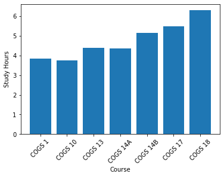

```python
# plot the bar graph
plt.bar(courses, avg_course_grd)

# styles x-axis, and adds axis labels.
plt.xticks(courses, labels, rotation=45)
plt.xlabel("Course")
plt.ylabel("Study Hours")
plt.show()
```

### Study Hours per Course (Upper Divs)

```
# Try it! - upper div courses

upperdiv_courses = ['COGS 100 - Cyborgs Now and in the Future',
'COGS 101A - Sensation and Perception',
'COGS 101B - Learning, Memory and Attention',
'COGS 107A - Neuroanatomy and Physiology',
'COGS 107B - Systems Neuroscience',
'COGS 108 - Data Science in Practice',
'COGS 109 - Modeling & Data Analysis']

# find average hours per course
avg_course_grd2 = []
for course in upperdiv_courses:
  avg_course_grd2.append(# fill this in!)

# create label names -- only include the course number (just makes things cleaner to look at)
labels = []
for i in upperdiv_courses:
  labels.append(i.split(" -")[0])

# plot the bar graph
plt.bar(# fill this in!, # fill this in!)

# styles x-axis, and adds axis labels.
plt.xticks(upperdiv_courses, labels, rotation=45)
plt.xlabel("Course")
plt.ylabel("Study Hours")
plt.show()
```

```python
upperdiv_courses = ['COGS 100 - Cyborgs Now and in the Future', # we give this
'COGS 101A - Sensation and Perception',
'COGS 101B - Learning, Memory and Attention',
'COGS 107A - Neuroanatomy and Physiology',
'COGS 107B - Systems Neuroscience',
'COGS 108 - Data Science in Practice',
'COGS 109 - Modeling & Data Analysis']

# find average hours per course
avg_course_grd2 = []
for course in upperdiv_courses:
  avg_course_grd2.append(cape_df[cape_df['Course'] == course]['Study Hours'].mean())

# create label names -- only include the course number
labels = []
for i in upperdiv_courses:
  labels.append(i.split(" -")[0])
```

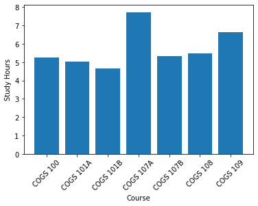

```python
# plot the bar graph
plt.bar(upperdiv_courses, avg_course_grd2)

plt.xticks(upperdiv_courses, labels, rotation=45)
plt.xlabel("Course")
plt.ylabel("Study Hours")
plt.show()
```

## Scatter Plot

### Study Hours vs. Grade

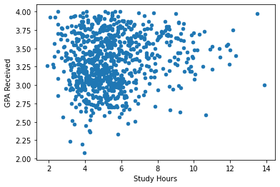

```python
cape_df.plot(kind='scatter', x='Study Hours', y='GPA Received')
```

### Grade Expected vs. Grade Received

```
# Try it!
cape_df.plot(kind='# Fill this in!', x='# Fill this in!', y='# Fill this in!')
```

```python
# might be helpful
list(cape_df.columns)
```

```
['Instructor',
 'Course',
 'Term',
 'Year',
 'Quarter',
 'Enroll',
 'Evaluations',
 'Recommend Class (%)',
 'Recommend Instructor (%)',
 'Study Hours',
 'Average Grade Expected',
 'GPA Expected',
 'Average Grade Received',
 'GPA Received']
```

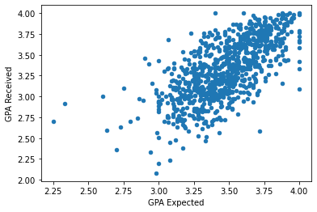

```python
# Try it!
cape_df.plot(kind='scatter', x='GPA Expected', y='GPA Received')
```

What's the correlation?

```python
cape_df[['GPA Expected','GPA Received']].corr()
```

|  | GPA Expected | GPA Received |
| --- | --- | --- |
| GPA Expected | 1.000000 | 0.683448 |
| GPA Received | 0.683448 | 1.000000 |

Let's add a best fit line.

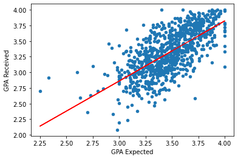

```python
cape_df.plot(kind='scatter', x='GPA Expected', y='GPA Received')

# plot line
x = cape_df['GPA Expected']
y = cape_df['GPA Received']
m, b = np.polyfit(x, y, 1)
plt.plot(x, m*x + b, 'r')
```

## Line Plots

### Enrollment Over Time

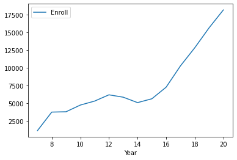

```python
# enrollment over time

enroll_df = cape_df[['Year','Enroll']]
enroll_per_yr = enroll_df.groupby(['Year']).sum()
enroll_per_yr.plot(kind='line')
```

### Average Grade Over Time

```
# Try It! - grade inflation????

grade_df = cape_df[['# fill this in!', '# fill this in!']]
grade_per_yr = grade_df.groupby(['# fill this in!']).mean()
grade_per_yr.plot(kind='# fill this in!')
```

```python
# might be helpful
list(cape_df.columns)
```

```
['Instructor',
 'Course',
 'Term',
 'Year',
 'Quarter',
 'Enroll',
 'Evaluations',
 'Recommend Class (%)',
 'Recommend Instructor (%)',
 'Study Hours',
 'Average Grade Expected',
 'GPA Expected',
 'Average Grade Received',
 'GPA Received']
```

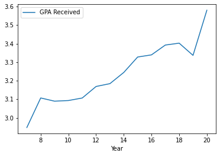

```python
# grade inflation????

grade_df = cape_df[['Year', 'GPA Received']]
grade_per_yr = grade_df.groupby(['Year']).mean()
grade_per_yr.plot(kind='line')
```

#### *But is this entirely accurate?*

- Each class is "weighted" the same, even though the enrollment number may be drastically different.

**Extra Challenge**

- How would you find the average grade over time, while taking into account the number of students enrolled?

# Thank You!

[Sign-In Form](https://forms.gle/QQerJxF38V5jQDSQ6)